# Nested For Loops

Kevin Patyk

12/22/2021

# Introduction

The placing of one `for` loop inside the body of another `for` loop is called nesting. When you “nest” two `for` loops, the outer loop takes control of the number of complete repetitions of the inner loop. Thus inner loop is executed N-times for every execution of outer loop.

# Examples

In this first example, we will be calculating the distances between the observations in vectors `x` and `y`.

```r
#define x and y
x <- 1:10
y <- 1:10

#create storage for the nested for loop
mat_out <- matrix(data = 0, nrow = 10, ncol = 10)

#rune the nested for loop
for(i in 1:length(x)){
  for(j in 1:length(y)){
    mat_out[i, j] <- (x[i] - y[j])
  }
}

mat_out
```

```
##       [,1] [,2] [,3] [,4] [,5] [,6] [,7] [,8] [,9] [,10]
##  [1,]    0   -1   -2   -3   -4   -5   -6   -7   -8    -9
##  [2,]    1    0   -1   -2   -3   -4   -5   -6   -7    -8
##  [3,]    2    1    0   -1   -2   -3   -4   -5   -6    -7
##  [4,]    3    2    1    0   -1   -2   -3   -4   -5    -6
##  [5,]    4    3    2    1    0   -1   -2   -3   -4    -5
##  [6,]    5    4    3    2    1    0   -1   -2   -3    -4
##  [7,]    6    5    4    3    2    1    0   -1   -2    -3
##  [8,]    7    6    5    4    3    2    1    0   -1    -2
##  [9,]    8    7    6    5    4    3    2    1    0    -1
## [10,]    9    8    7    6    5    4    3    2    1     0
```

So, what exactly happened here? The outer loop runs a total of 10 times since there are 10 observations in `x` (`1:length(x)`). And, for every single one of those 10 runs, the inner loop runs 10 times as well since there are 10 observations in `y` (`1:length(y)`). In this case, there are a total of 100 iterations ($10 \cdot 10 = 100$). Each iteration looks like the code below.

```r
#creating a new storage matrix
mat_out2 <- matrix(data = 0, nrow = 10, ncol = 10)

#iteration 1
(mat_out2[1, 1:10] <- (x[1] - y[1:10]))
```

```
##  [1]  0 -1 -2 -3 -4 -5 -6 -7 -8 -9
```

```r
#iteration 2
(mat_out2[2, 1:10] <- (x[2] - y[1:10]))
```

```
##  [1]  1  0 -1 -2 -3 -4 -5 -6 -7 -8
```

```r
#iteration 3
(mat_out2[3, 1:10] <- (x[3] - y[1:10]))
```

```
##  [1]  2  1  0 -1 -2 -3 -4 -5 -6 -7
```

```r
#iteration 4
(mat_out2[4, 1:10] <- (x[4] - y[1:10]))
```

```
##  [1]  3  2  1  0 -1 -2 -3 -4 -5 -6
```

```r
#iteration 5
(mat_out2[5, 1:10] <- (x[5] - y[1:10]))
```

```
##  [1]  4  3  2  1  0 -1 -2 -3 -4 -5
```

```r
#iteration 6
(mat_out2[6, 1:10] <- (x[6] - y[1:10]))
```

```
##  [1]  5  4  3  2  1  0 -1 -2 -3 -4
```

```r
#iteration 7
(mat_out2[7, 1:10] <- (x[7] - y[1:10]))
```

```
##  [1]  6  5  4  3  2  1  0 -1 -2 -3
```

```r
#iteration 8
(mat_out2[8, 1:10] <- (x[8] - y[1:10]))
```

```
##  [1]  7  6  5  4  3  2  1  0 -1 -2
```

```r
#iteration 9
(mat_out2[9, 1:10] <- (x[9] - y[1:10]))
```

```
##  [1]  8  7  6  5  4  3  2  1  0 -1
```

```r
#iteration 10
(mat_out2[10, 1:10] <- (x[10] - y[1:10]))
```

```
##  [1] 9 8 7 6 5 4 3 2 1 0
```

As you can see, we get exactly the same result as when we run the nested `for` loop. To put it in different terms, for each iteration of `i`, `j` runs 10 times. In this case, we replaced `j` with `1:10` to make the code shorter. But, when running the nested `for` loop, it actually looks something like this, which will be kept short because it would otherwise be way too much to read. This is how the first 10 iterations of the `for` loop would look like.

```r
#creating a new storage matrix
mat_out3 <- matrix(data = 0, nrow = 10, ncol = 10)

#iteration 1
(mat_out3[1, 1] <- (x[1] - y[1]))
```

```
## [1] 0
```

```r
#iteration 2
(mat_out3[1, 2] <- (x[1] - y[2]))
```

```
## [1] -1
```

```r
#iteration 3
(mat_out3[1, 3] <- (x[1] - y[3]))
```

```
## [1] -2
```

```r
#iteration 4
(mat_out3[1, 4] <- (x[1] - y[4]))
```

```
## [1] -3
```

```r
#iteration 5
(mat_out3[1, 5] <- (x[1] - y[5]))
```

```
## [1] -4
```

```r
#iteration 6
(mat_out3[1, 6] <- (x[1] - y[6]))
```

```
## [1] -5
```

```r
#iteration 7
(mat_out2[1, 7] <- (x[1] - y[7]))
```

```
## [1] -6
```

```r
#iteration 8
(mat_out3[1, 8] <- (x[1] - y[8]))
```

```
## [1] -7
```

```r
#iteration 9
(mat_out3[1, 9] <- (x[1] - y[9]))
```

```
## [1] -8
```

```r
#iteration 10
(mat_out3[1, 10] <- (x[1] - y[10]))
```

```
## [1] -9
```

Now, for another example where we will be calculating the distances between all points in a matrix.

```r
#making a short data frame
df <- iris[c(1:5, 51:55, 101:105), -5]

#examining the first 6 observations
head(df)
```

```
##    Sepal.Length Sepal.Width Petal.Length Petal.Width
## 1           5.1         3.5          1.4         0.2
## 2           4.9         3.0          1.4         0.2
## 3           4.7         3.2          1.3         0.2
## 4           4.6         3.1          1.5         0.2
## 5           5.0         3.6          1.4         0.2
## 51          7.0         3.2          4.7         1.4
```

```r
#fixing the rownames
rownames(df) <- NULL

#converting the data frame into a matrix
mat <- as.matrix(df)
```

Now, we will create a nested for loop to calculate the Euclidean distances between all of the points. In other words, we want to find the distances between points row-wise (differences between rows 1 and 1, rows 1 and 2, rows 1 and 3, …, rows 2 and 1, rows 2 and 2, rows 2 and 3, …, rows 3 and 1, rows 3 and 2, rows 3 and 3, …, rows n and n).

*Note*: Even though there are 4 variables and 1 observation per variable, making 4 observations per row, there will only be one number as the output for the Euclidean distance because of summation. The formula for Euclidean distance is below:

$$||a-b||_2 = \sqrt{\Sigma(a_i-b_i)^2}$$

Now, to create the nested `for` loop.

```r
#create storage for the nested for loop
mat_out <- matrix(data = 0, nrow = nrow(mat), ncol = nrow(mat))

#creating a nested for loop to calculate the euclidean distances between all points
for (i in 1:nrow(mat)){
  for (j in 1:nrow(mat)){
  mat_out[i,j] <- round(sqrt(sum((mat[i, ] - mat[j, ])^2)), digits = 2)
  }
}

mat_out
```

```
##       [,1] [,2] [,3] [,4] [,5] [,6] [,7] [,8] [,9] [,10] [,11] [,12] [,13]
##  [1,] 0.00 0.54 0.51 0.65 0.14 4.00 3.62 4.16 3.09  3.79  5.28  4.21  5.30
##  [2,] 0.54 0.00 0.30 0.33 0.61 4.10 3.69 4.24 2.97  3.81  5.34  4.18  5.36
##  [3,] 0.51 0.30 0.00 0.24 0.51 4.28 3.85 4.42 3.15  4.00  5.47  4.33  5.53
##  [4,] 0.65 0.33 0.24 0.00 0.65 4.18 3.73 4.31 2.98  3.87  5.34  4.18  5.41
##  [5,] 0.14 0.61 0.51 0.65 0.00 4.06 3.66 4.22 3.15  3.85  5.31  4.25  5.35
##  [6,] 4.00 4.10 4.28 4.18 4.06 0.00 0.64 0.26 1.89  0.66  1.84  1.45  1.41
##  [7,] 3.62 3.69 3.85 3.73 3.66 0.64 0.00 0.65 1.38  0.42  1.81  1.06  1.69
##  [8,] 4.16 4.24 4.42 4.31 4.22 0.26 0.65 0.00 1.86  0.58  1.62  1.25  1.19
##  [9,] 3.09 2.97 3.15 2.98 3.15 1.89 1.38 1.86 0.00  1.28  2.66  1.35  2.70
## [10,] 3.79 3.81 4.00 3.87 3.85 0.66 0.42 0.58 1.28  0.00  1.80  0.95  1.57
## [11,] 5.28 5.34 5.47 5.34 5.31 1.84 1.81 1.62 2.66  1.80  0.00  1.33  0.95
## [12,] 4.21 4.18 4.33 4.18 4.25 1.45 1.06 1.25 1.35  0.95  1.33  0.00  1.57
## [13,] 5.30 5.36 5.53 5.41 5.35 1.41 1.69 1.19 2.70  1.57  0.95  1.57  0.00
## [14,] 4.69 4.71 4.87 4.72 4.73 1.24 1.18 0.99 1.95  1.07  0.90  0.74  0.91
```

[output cut: 17 more lines]

So, what exactly happened here? The outer loop runs a total of 15 times since there are 15 rows in `mat` (`1:nrow(mat)`). And, for every single one of those 15 runs, the inner loop runs 15 times as well since there are 15 rows in `mat` (`1:nrow(mat)`). In this case, there are a total of 225 iterations ($15 \cdot 15 = 225$).

```r
#creating a new storage matrix
mat_out2 <- matrix(data = 0, nrow = 15, ncol = 15)

#iteration 1
(mat_out2[1, 1] <- round(sqrt(sum((mat[1, ] - mat[1, ])^2)), digits = 2))
```

```
## [1] 0
```

```r
#iteration 2
(mat_out2[1, 2] <- round(sqrt(sum((mat[1, ] - mat[2, ])^2)), digits = 2))
```

```
## [1] 0.54
```

```r
#iteration 3
(mat_out2[1, 3] <- round(sqrt(sum((mat[1, ] - mat[3, ])^2)), digits = 2))
```

```
## [1] 0.51
```

```r
#iteration 4
(mat_out2[1, 4] <- round(sqrt(sum((mat[1, ] - mat[4, ])^2)), digits = 2))
```

```
## [1] 0.65
```

```r
#iteration 5
(mat_out2[1, 5] <- round(sqrt(sum((mat[1, ] - mat[5, ])^2)), digits = 2))
```

```
## [1] 0.14
```

```r
#iteration 6
(mat_out2[1, 6] <- round(sqrt(sum((mat[1, ] - mat[6, ])^2)), digits = 2))
```

```
## [1] 4
```

```r
#iteration 7
(mat_out2[1, 7] <- round(sqrt(sum((mat[1, ] - mat[7, ])^2)), digits = 2))
```

```
## [1] 3.62
```

```r
#iteration 8
(mat_out2[1, 8] <- round(sqrt(sum((mat[1, ] - mat[8, ])^2)), digits = 2))
```

```
## [1] 4.16
```

```r
#iteration 9
(mat_out2[1, 9] <- round(sqrt(sum((mat[1, ] - mat[9, ])^2)), digits = 2))
```

```
## [1] 3.09
```

```r
#iteration 10
(mat_out2[1, 10] <- round(sqrt(sum((mat[1, ] - mat[10, ])^2)), digits = 2))
```

```
## [1] 3.79
```

```r
#iteration 11
(mat_out2[1, 11] <- round(sqrt(sum((mat[1, ] - mat[11, ])^2)), digits = 2))
```

```
## [1] 5.28
```

```r
#iteration 12
(mat_out2[1, 12] <- round(sqrt(sum((mat[1, ] - mat[12, ])^2)), digits = 2))
```

```
## [1] 4.21
```

```r
#iteration 13
(mat_out2[1, 13] <- round(sqrt(sum((mat[1, ] - mat[13, ])^2)), digits = 2))
```

```
## [1] 5.3
```

```r
#iteration 14
(mat_out2[1, 14] <- round(sqrt(sum((mat[1, ] - mat[14, ])^2)), digits = 2))
```

```
## [1] 4.69
```

```r
#iteration 15
(mat_out2[1, 15] <- round(sqrt(sum((mat[1, ] - mat[15, ])^2)), digits = 2))
```

```
## [1] 5.06
```

```r
mat_out2
```

```
##       [,1] [,2] [,3] [,4] [,5] [,6] [,7] [,8] [,9] [,10] [,11] [,12] [,13]
##  [1,]    0 0.54 0.51 0.65 0.14    4 3.62 4.16 3.09  3.79  5.28  4.21   5.3
##  [2,]    0 0.00 0.00 0.00 0.00    0 0.00 0.00 0.00  0.00  0.00  0.00   0.0
##  [3,]    0 0.00 0.00 0.00 0.00    0 0.00 0.00 0.00  0.00  0.00  0.00   0.0
##  [4,]    0 0.00 0.00 0.00 0.00    0 0.00 0.00 0.00  0.00  0.00  0.00   0.0
##  [5,]    0 0.00 0.00 0.00 0.00    0 0.00 0.00 0.00  0.00  0.00  0.00   0.0
##  [6,]    0 0.00 0.00 0.00 0.00    0 0.00 0.00 0.00  0.00  0.00  0.00   0.0
##  [7,]    0 0.00 0.00 0.00 0.00    0 0.00 0.00 0.00  0.00  0.00  0.00   0.0
##  [8,]    0 0.00 0.00 0.00 0.00    0 0.00 0.00 0.00  0.00  0.00  0.00   0.0
##  [9,]    0 0.00 0.00 0.00 0.00    0 0.00 0.00 0.00  0.00  0.00  0.00   0.0
## [10,]    0 0.00 0.00 0.00 0.00    0 0.00 0.00 0.00  0.00  0.00  0.00   0.0
## [11,]    0 0.00 0.00 0.00 0.00    0 0.00 0.00 0.00  0.00  0.00  0.00   0.0
## [12,]    0 0.00 0.00 0.00 0.00    0 0.00 0.00 0.00  0.00  0.00  0.00   0.0
## [13,]    0 0.00 0.00 0.00 0.00    0 0.00 0.00 0.00  0.00  0.00  0.00   0.0
## [14,]    0 0.00 0.00 0.00 0.00    0 0.00 0.00 0.00  0.00  0.00  0.00   0.0
```

[output cut: 17 more lines]

As you can see, we get exactly the same result as when we run the nested `for` loop. To put it in different terms, for each iteration of `i`, `j` runs 15 times. In this case, we replaced `j` with the respective numbers (`1:15`) so that you can see what happens during the first 15 iterations of the `for` loop.

Let’s do another example, but keep it a bit more simple this time. In this example, we will make a nested `for` loop that multiplies numbers from 2 vectors together. The 2 vectors are `1:5` and `1:2`. Thus, there will be a total of 10 iterations ($5 \cdot 2 = 10$). At each iteration, we will `print()` the result of the multiplication.

```r
for(i in 1:5){
  for(j in 1:2){
    print(i*j)
  }
}
```

```
## [1] 1
## [1] 2
## [1] 2
## [1] 4
## [1] 3
## [1] 6
## [1] 4
## [1] 8
## [1] 5
## [1] 10
```

So, what exactly happened here? We will break it down again line by line for a more complete understanding. For each iteration of `i`, `j` runs 2 times.

```r
#iteration 1
print(1*1)
```

```
## [1] 1
```

```r
#iteration 2
print(1*2)
```

```
## [1] 2
```

```r
#iteration 3
print(2*1)
```

```
## [1] 2
```

```r
#iteration 4
print(2*2)
```

```
## [1] 4
```

```r
#iteration 5
print(3*1)
```

```
## [1] 3
```

```r
#iteration 6
print(3*2)
```

```
## [1] 6
```

```r
#iteration 7
print(4*1)
```

```
## [1] 4
```

```r
#iteration 8
print(4*2)
```

```
## [1] 8
```

```r
#iteration 9
print(5*1)
```

```
## [1] 5
```

```r
#iteration 10
print(5*2)
```

```
## [1] 10
```

And we get exactly the same results as the nested `for` loop. There are plenty of other examples that can be done and some practice is required. It is definitely worth learning since nested `for` loops can facilitate many tasks.

As one last note, I have made a helpful image to display how a nested `for` loop works. I like to imagine the process like First Outside Inside Last (FOIL). FOIL is used when multiplying 2 binomials and is a very common mnemonic. Below is a visualization to show you what I mean:

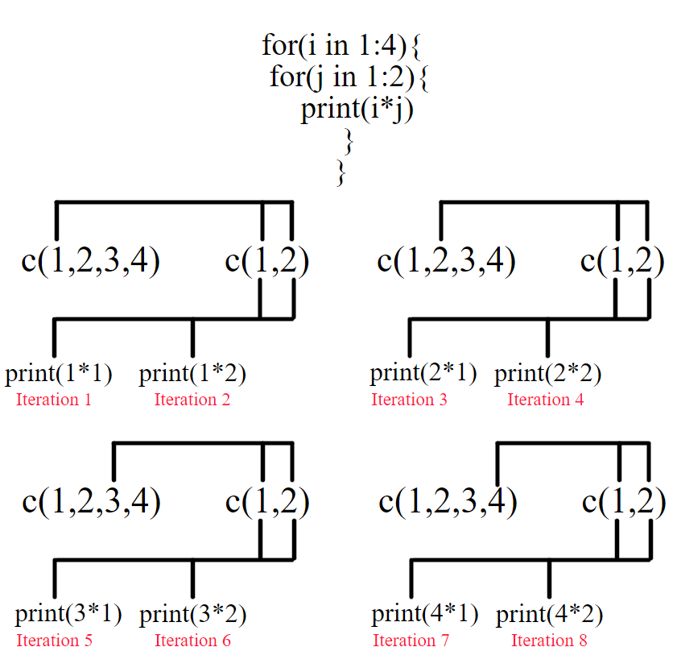